# R Notebook

## # Analisis con datos simulados

# Varias variables : solo porque son quantitativas

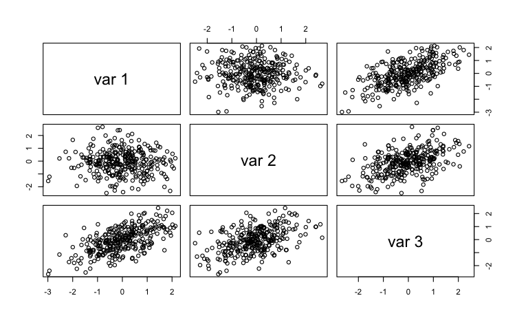

```r
#-------------------------------------------------------#
# Ejemplo: M?s dimensiones                              #
#-------------------------------------------------------#
load(file = "3dExample.rda")
#load(file = file.choose())
pairs(dat)
```

No se puede apreciar los outlier porque son 3 variables a considerar, podemos confundirnos pensando como 1 o 2 varibles, graficamente no se puede hacer

```r
head(dat)
```

```
           [,1]       [,2]       [,3]
[1,] -1.4805676 -1.4813921 -2.5266517
[2,]  1.5771695 -0.9303329  1.1101536
[3,] -0.9567445 -1.0166150 -1.2225865
[4,] -0.9200052 -0.2116883 -0.2298953
[5,] -1.9976421  1.6528664 -0.5805634
[6,] -0.2722960  0.7252966  1.0528182
```

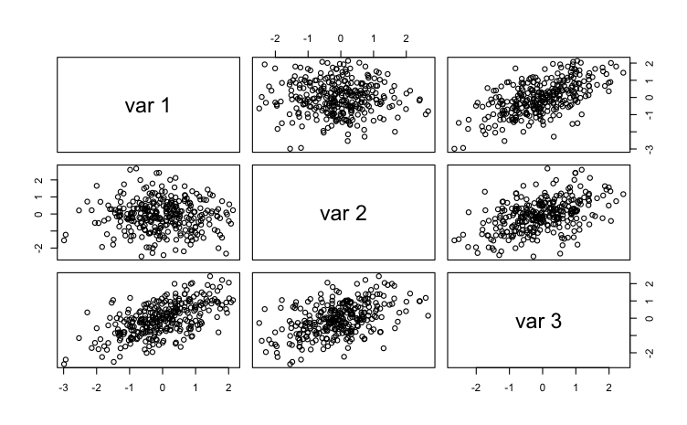

```r
# Introduciendo outliers
outFactor <- 1.5  # Factor de inflacion
dat <- rbind(dat, outFactor*c(-1,-1.2,0.7))
pairs(dat)
```

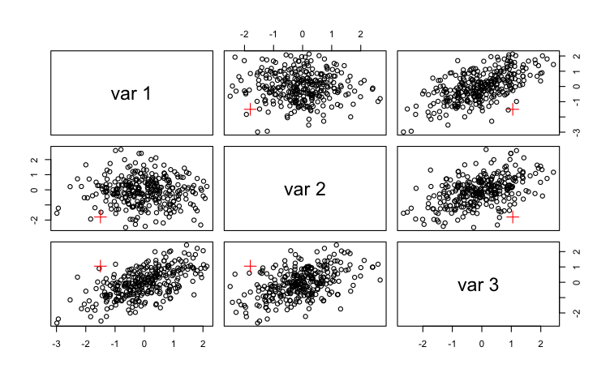

```r
pairs(dat, col = c(rep(1,300), 2), pch = c(rep(1,300), 3), cex = c(rep(1,300), 2))
```

No se aprecia los outlier comparando con el grafico de dispersion inicial

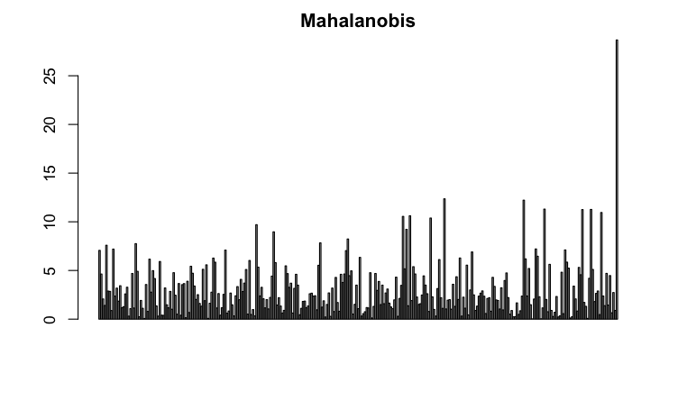

```r
d <- mahalanobis(dat, colMeans(dat), cov(dat))
barplot(d, main="Mahalanobis")
```

```r
which.max(d)
```

```
[1] 301
```

```r
str(d)
```

[output not shown]

En la grafica de la distancia de Mahalanobis se puede apreciar el potencial outlier

[figure not shown]

```r
# QQ-plot:
par(mfrow=c(1,1))
# Como tengo 3 variables ahora tengo 3 grados de libertad
qqplot(d, qchisq(ppoints(301), df = 3),
       main = expression("Q-Q plot for" ~~ {chi^2}[nu == 3]))
```

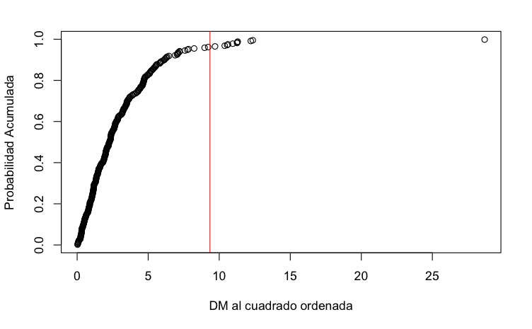

```r
plot(sort(d), ppoints(301), xlab ="DM al cuadrado ordenada", ylab = "Probabilidad Acumulada")
Q <- qchisq(p = 0.975, df = 3)
abline(v=Q, col = "red")
```

```r
install.packages("XQuartz")
```

```r
install.packages("rgl")
```

```r
library(rgl)
```

[output not shown]

## # Analisis con datos reales

# Varias variables : solo porque son quantitativas

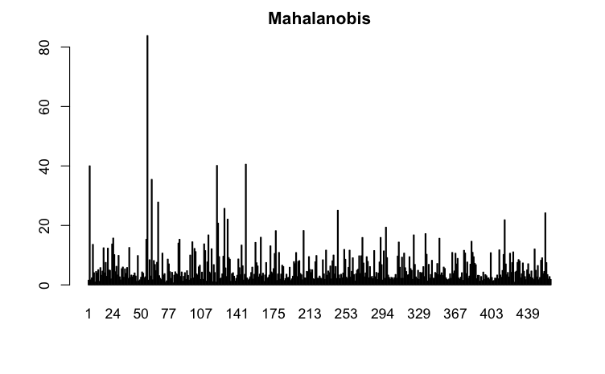

```r
#-------------------------------------------------------#
#  Ejemplo: Empleados de Midwestern bank (1965)         #
# ------------------------------------------------------#

dat <- Bank[c(2,4,5,6,7,8)]
d <- mahalanobis(dat, colMeans(dat), cov(dat))
barplot(d, main="Mahalanobis")
```

```r
which.max(d)
```

```
56
56
```

```r
# Buscamos al empleado que es el potencial outlier

Bank[56,]
```

|  | ID | SALBEG | GENDER | JOBTIME | AGE | SALNOW | EDLEVEL | WORKEXP | JOBCAT | MINORITY |
| --- | --- | --- | --- | --- | --- | --- | --- | --- | --- | --- |
| 56 | 779 | 31992 | Hombre | 96 | 49 | 54000 | 19 | 16.58 | T?cnico | Blanco |

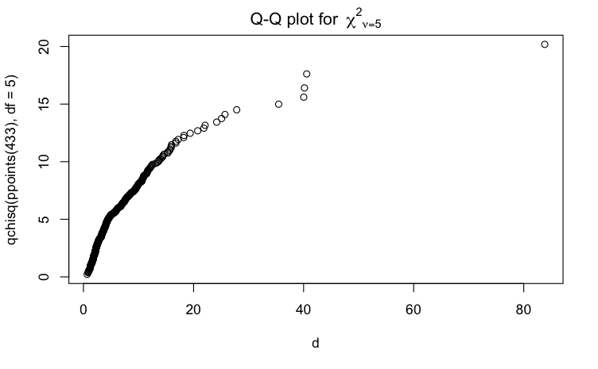

```r
# Se pone 433 porque es la cantidad de datos
# Se pone 6 porque tengo esa cantdad de variable
# QQ-plot:
par(mfrow=c(1,1))
qqplot(d, qchisq(ppoints(433), df = 5),
       main = expression("Q-Q plot for" ~~ {chi^2}[nu == 5]))
```

```r
NA
NA
```

# Grafica de la ojiva

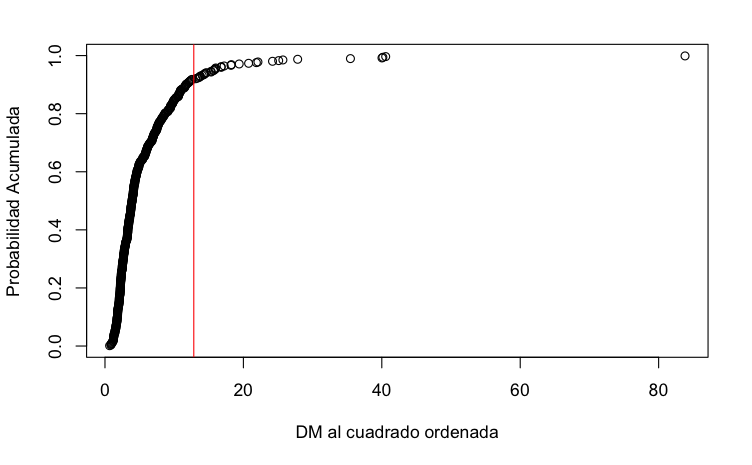

```r
plot(sort(d), ppoints(433), xlab ="DM al cuadrado ordenada", ylab = "Probabilidad Acumulada")
Q <- qchisq(p = 0.975, df = 5)
abline(v=Q, col = "red")
```

Si hubiesen varios outlier , afectarian a las media y a los covarianzas, por lo tanto se podrian afectar, por lo tanto fallaria para estaos casos

# Estimadores robustos

Debemos usar una estimaciones robustas: - El estimador de elipsoide de volumen minimo : MVE - El estimador de determinante de covarianza minima : MCD

Es mas robusto pero es mas lento de ser procesado

# Cuando debemos usar los estimadores robustos

- Efecto de enmascaramiento : Ocurre cuando despues de eliminar un outlier, otra observacion se vuelve outlier.
- Efecto de cubrimiento : Ocurre cuando despues de eliminar un outlier, otro outlier se vuelve en una buena observacion.

“Cuando sucede esto, la distancia tradicional de Mahalanobis ya no funciona y hay que usar un estimador robusto”

# Libreria mvoutlier

Se usa para usar estimadores robusto

```r
install.packages("mvoutlier")
```

[output not shown]

[output cut: 10 more lines]

```
FALSE FALSE FALSE FALSE  TRUE FALSE  TRUE  TRUE  TRUE FALSE  TRUE FALSE FALSE FALSE
  358   359   360   361   364   365   366   367   368   369   370   371   372   373
FALSE FALSE FALSE FALSE  TRUE FALSE FALSE  TRUE  TRUE  TRUE FALSE FALSE FALSE  TRUE
  374   375   376   377   378   379   380   381   382   383   384   385   386   387
 TRUE  TRUE FALSE FALSE  TRUE FALSE FALSE  TRUE  TRUE  TRUE FALSE  TRUE FALSE FALSE
  388   389   390   391   393   394   395   396   397   398   399   401   402   403
FALSE FALSE FALSE FALSE FALSE FALSE  TRUE  TRUE FALSE FALSE FALSE FALSE  TRUE FALSE
  404   405   406   407   408   409   410   411   412   413   414   415   416   417
FALSE FALSE FALSE FALSE FALSE FALSE  TRUE FALSE FALSE FALSE  TRUE  TRUE  TRUE  TRUE
  418   419   420   421   422   423   424   425   426   427   428   429   430   431
FALSE FALSE  TRUE  TRUE  TRUE  TRUE FALSE FALSE FALSE FALSE  TRUE FALSE  TRUE FALSE
  432   433   434   435   438   439   440   442   443   444   453   454   455   456
 TRUE FALSE FALSE FALSE  TRUE  TRUE FALSE  TRUE  TRUE FALSE  TRUE  TRUE  TRUE  TRUE
  460   461   462   463   464   465   467   468   469   470   471   473   474
 TRUE  TRUE FALSE  TRUE FALSE FALSE  TRUE  TRUE  TRUE FALSE FALSE  TRUE  TRUE
```

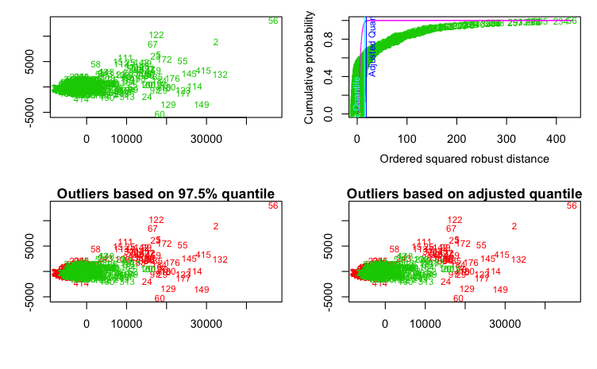

```r
#--------------------------------------------------------------------------------------- #
#  Ejemplo: Estimadores robustos                                                       #
# Ver Filzmoser et al. (2005) Multivariate outlier detection in exploration geochemistry #
#----------------------------------------------------------------------------------------#

library(mvoutlier)
aq.plot(dat)
```

[output not shown]

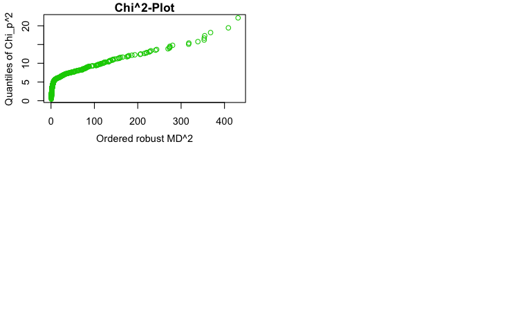

```r
chisq.plot(dat)
```

[output not shown]

[output cut: 246 more lines]

[output not shown]

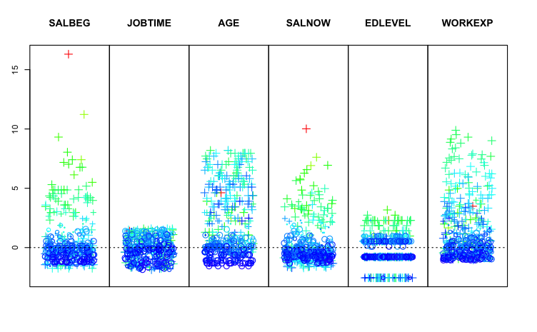

```r
uni.plot(dat,symb = TRUE)
```

Se usa en la OJIVA la distancia de Mahanomis al cuadrado

Las que aparecen en rojo

CRITICA : - No se identifica el centro claramente - Algunas veces el centro no es el valor adecuado para tenerlo de refencia para calcular el outlier.

```
 Supongamos que deseamos ver los diagramas de dispersion


      |                 . .
      |                 .. .
      |            . ..
      |         ....
      |       . .               Se puede calcular el valor del centro adecuadamente
      |    . .  .
      |    .  .
      |  .  .
      | .
      |----------------------------




      |      ....           . .
      |     ...            .. .
      |        ..      . ..
      |                 ....
      |       . .               Se puede calcular el valor del centro usando el concepto
      |    . .  .     ....      de vencidad.
      |    .  .     . ...
      |  .  .        ...
      | .               ..
      |----------------------------
```

# Outliers Multivariados (Otros m?todos)

# Leer los papers para ver cual es el criterio

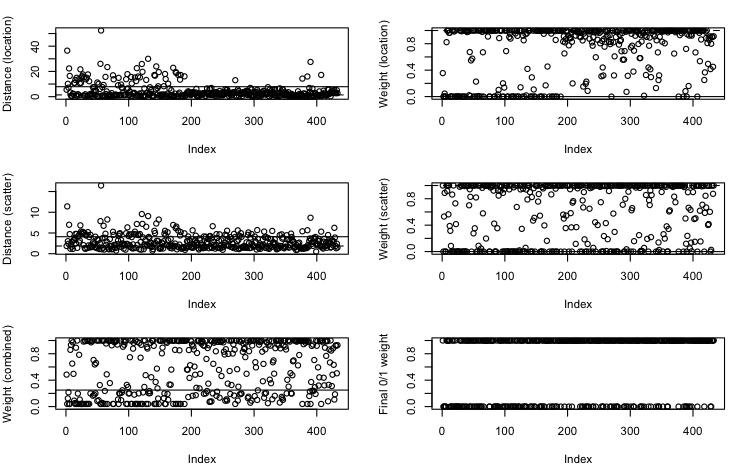

```r
# PCOut Method (robust principal components - m?s adecuado para grandes dimensiones)
# Ver Filzmoser et al. (2008) Outlier identification in high dimensions
outlier=pcout(dat, makeplot = TRUE)
```

```r
outlier
```

[output not shown]

[output cut: 653 more lines]

```
       468        469        470        471        473        474
 6.2507713  3.9093645  1.8684658  1.3135795  2.4296990  1.4972830

$M1
33.33333%
 1.390833

$const1
[1] 7.899433

$M2
[1] 1.858655

$const2
[1] 4.100231
```

```r
# outlier$wfinal : me devuelve el valor de los posibles potenciales que pueden ser outlier
Bank[order(outlier$wfinal,decreasing=F)[1:10],]
```

|  | ID | SALBEG | GENDER | JOBTIME | AGE | SALNOW | EDLEVEL | WORKEXP | JOBCAT | MINORITY |
| --- | --- | --- | --- | --- | --- | --- | --- | --- | --- | --- |
| 2 | 630 | 24000 | Hombre | 73 | 40 | 41400 | 16 | 12.50 | Empleado | Blanco |
| 5 | 635 | 17400 | Hombre | 83 | 41 | 28350 | 19 | 13.00 | Empleado | Blanco |
| 6 | 637 | 12996 | Hombre | 80 | 29 | 27250 | 18 | 2.42 | Acad?mico | Blanco |
| 15 | 659 | 13200 | Hombre | 64 | 31 | 19020 | 19 | 2.25 | Empleado | Blanco |
| 17 | 669 | 13500 | Hombre | 81 | 30 | 22200 | 19 | 5.17 | Acad?mico | Blanco |
| 20 | 685 | 11004 | Hombre | 89 | 34 | 27500 | 17 | 3.17 | Acad?mico | Blanco |
| 23 | 697 | 16992 | Hombre | 85 | 43 | 27700 | 20 | 11.17 | T?cnico | Blanco |
| 24 | 702 | 8700 | Hombre | 65 | 28 | 28000 | 16 | 1.58 | Acad?mico | Blanco |
| 25 | 704 | 13992 | Hombre | 65 | 39 | 22000 | 19 | 10.75 | Empleado | Blanco |
| 26 | 706 | 12804 | Hombre | 78 | 30 | 27250 | 19 | 2.92 | Acad?mico | Blanco |

Sale los posible outlier

```r
# Sign Method
outlier1=sign2(dat)
outlier1
```

[output not shown]

[output cut: 86 more lines]

```
       418        419        420        421        422        423        424
 2.2225913  1.6197485  4.5363461  3.3151066  4.4739972  5.0718242  0.8077400
       425        426        427        428        429        430        431
 2.7501530  2.0623626  2.7415618  4.3661093  2.3519583  2.4616736  1.7823054
       432        433        434        435        438        439        440
 5.0430407  1.7598213  1.3141064  1.1456339  3.0155977  3.8278787  1.6130282
       442        443        444        453        454        455        456
 2.1757470  2.8052903  1.1252997  2.0248713  4.6680067  3.7965309  2.3495007
       460        461        462        463        464        465        467
 3.5305756  1.6727706  1.4919644  3.7121842  2.4367013  1.6995664  2.9988755
       468        469        470        471        473        474
 6.7734068  3.9583864  1.6298742  1.3983481  3.0459681  1.6394636

$const
[1] 3.801233
```

```r
Bank[order(outlier1$x.dist,decreasing=T)[1:10],]
```

|  | ID | SALBEG | GENDER | JOBTIME | AGE | SALNOW | EDLEVEL | WORKEXP | JOBCAT | MINORITY |
| --- | --- | --- | --- | --- | --- | --- | --- | --- | --- | --- |
| 56 | 779 | 31992 | Hombre | 96 | 49 | 54000 | 19 | 16.58 | T?cnico | Blanco |
| 2 | 630 | 24000 | Hombre | 73 | 40 | 41400 | 16 | 12.50 | Empleado | Blanco |
| 122 | 950 | 21000 | Hombre | 83 | 49 | 26700 | 16 | 21.50 | T?cnico | Blanco |
| 67 | 808 | 18996 | Hombre | 86 | 42 | 26400 | 16 | 12.50 | Empleado | Blanco |
| 149 | 1005 | 11004 | Hombre | 97 | 37 | 41500 | 16 | 5.83 | Empleado | Blanco |
| 132 | 973 | 18000 | Hombre | 96 | 39 | 44250 | 19 | 10.00 | T?cnico | Blanco |
| 415 | 948 | 17640 | Hombre | 66 | 35 | 40000 | 16 | 10.67 | Empleado | No blanco |
| 55 | 778 | 18000 | Hombre | 66 | 34 | 34500 | 18 | 4.17 | T?cnico | Blanco |
| 60 | 786 | 6300 | Hombre | 82 | 29 | 32000 | 15 | 2.83 | Asistente | Blanco |
| 5 | 635 | 17400 | Hombre | 83 | 41 | 28350 | 19 | 13.00 | Empleado | Blanco |

Sale como posible outlier la observacion 56

```r
# Densidad Local
library(DMwR)
lof=lofactor(dat,10)
lof
```

```
  [1] 1.1393708 1.8043773 0.9733684 0.9876981 1.5657395 0.9711284 1.0390732 1.1209161
  [9] 1.2113814 1.0375532 0.9981858 1.0618558 0.9978690 1.0016641 1.3172143 1.4919040
 [17] 1.0445935 1.2847987 1.1814037 1.0513454 1.2253197 1.1004882 1.4972860 1.4505971
 [25] 1.0957708 0.9810295 0.9764020 1.1984752 1.0858892 1.0786706 0.9876739 1.0414522
 [33] 1.0017625 0.9767478 1.1389515 1.0544807 0.9859713 0.9581779 1.0396700 1.8125769
 [41] 1.0544467 0.9440444 1.4622282 1.1730719 1.0080436 1.1386073 0.9853013 1.1922512
 [49] 0.9864758 0.9818134 0.9921218 0.9914694 1.0000175 1.4652223 1.2495442 3.2296080
 [57] 0.9595323 2.5916561 0.9856809 1.6913215 0.9668383 0.9594768 1.0011015 1.0242748
 [65] 1.0415129 1.8176961 1.1476953 0.9717981 1.1021634 1.0142587 0.9863626 1.0015873
 [73] 0.9732796 1.0568091 1.1160381 0.9707855 1.2361668 1.1602275 0.9954576 1.1281323
 [81] 1.1946648 1.4053119 1.0264286 0.9637269 1.0268336 1.0682270 1.0331171 1.0459900
 [89] 0.9823546 1.0296263 1.3529825 1.1191030 1.0501017 0.9698387 1.1126859 1.0899388
 [97] 1.0500227 1.0676195 1.0191726 1.1980618 1.1210748 1.0981898 1.2674473 0.9725358
[105] 1.0529349 1.0152539 0.9898350 0.9736870 1.0011223 1.2800727 0.9842426 1.1634525
[113] 1.2757133 1.0811625 0.9747448 1.1333967 1.0030009 1.0666795 0.9594786 1.0351485
```

[output cut: 40 more lines]

```r
Bank[order(lof,decreasing=T)[1:10],]
```

|  | ID | SALBEG | GENDER | JOBTIME | AGE | SALNOW | EDLEVEL | WORKEXP | JOBCAT | MINORITY |
| --- | --- | --- | --- | --- | --- | --- | --- | --- | --- | --- |
| 56 | 779 | 31992 | Hombre | 96 | 49 | 54000 | 19 | 16.58 | T?cnico | Blanco |
| 58 | 783 | 11100 | Hombre | 82 | 44 | 13848 | 16 | 12.42 | Oficinista | Blanco |
| 122 | 950 | 21000 | Hombre | 83 | 49 | 26700 | 16 | 21.50 | T?cnico | Blanco |
| 414 | 926 | 3600 | Hombre | 91 | 53 | 12300 | 12 | 26.17 | Seguridad | No blanco |
| 236 | 743 | 7500 | Mujer | 90 | 61 | 12600 | 12 | 17.08 | Asistente | Blanco |
| 231 | 732 | 7500 | Mujer | 68 | 51 | 10080 | 8 | 28.67 | Oficinista | Blanco |
| 67 | 808 | 18996 | Hombre | 86 | 42 | 26400 | 16 | 12.50 | Empleado | Blanco |
| 40 | 740 | 7800 | Hombre | 83 | 38 | 11736 | 12 | 12.50 | Oficinista | Blanco |
| 2 | 630 | 24000 | Hombre | 73 | 40 | 41400 | 16 | 12.50 | Empleado | Blanco |
| 60 | 786 | 6300 | Hombre | 82 | 29 | 32000 | 15 | 2.83 | Asistente | Blanco |

Sale como posible outlier la observacion 56